# Introduction to hypothesis tests

```r
library(tidyverse)
library(janitor)
library(infer)
```

```r
books <- read_csv("data/books.csv") %>%
  clean_names()
```

```r
books_tidy <- books %>%
  filter(!is.na(average_rating)) %>%
  rename(num_page = number_num_pages)

glimpse(books_tidy)
```

```
Rows: 10,999
Columns: 10
$ book_id            <dbl> 1, 2, 3, 4, 5, 8, 9, 10, 12, 13, 14, 16, 18, 21, 22, 23, 24, 25, ~
$ title              <chr> "Harry Potter and the Half-Blood Prince (Harry Potter  #6)", "Har~
$ authors            <chr> "J.K. Rowling-Mary GrandPré", "J.K. Rowling-Mary GrandPré", "J.K.~
$ average_rating     <dbl> 4.56, 4.49, 4.47, 4.41, 4.55, 4.78, 3.69, 4.73, 4.38, 4.38, 4.22,~
$ isbn               <chr> "0439785960", "0439358078", "0439554934", "0439554896", "04396554~
$ isbn13             <chr> "9780439785969", "9780439358071", "9780439554930", "9780439554893~
$ language_code      <chr> "eng", "eng", "eng", "eng", "eng", "eng", "en-US", "eng", "eng", ~
$ num_page           <dbl> 652, 870, 320, 352, 435, 2690, 152, 3342, 815, 815, 215, 6, 815, ~
$ ratings_count      <dbl> 1944099, 1996446, 5629932, 6267, 2149872, 38872, 18, 27410, 3602,~
$ text_reviews_count <dbl> 26249, 27613, 70390, 272, 33964, 154, 1, 820, 258, 3954, 408, 253~
```

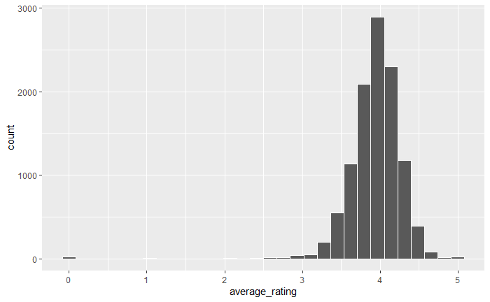

```r
books_tidy %>%
  ggplot(aes(x = average_rating)) +
  geom_histogram(col = "white")
```

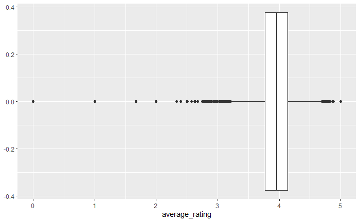

```r
books_tidy %>%
  ggplot(aes(x = average_rating)) +
  geom_boxplot()
```

Again, remember here, if we had data for the population (i.e. the 2020 Goodreads database) then we wouldn’t need to perform a hypothesis test. We could just look at descriptive statistics i.e. calculate the population mean from this full database and see how it compares to 3.93. But we have only a sample of the population, so we have to use inferential techniques to make predictions about the population.

We frame this question in terms of two competing hypotheses:

- $H_0$: (the **null** hypothesis, pronounced ‘H naught’) - the current mean `average_rating` **is the same as** the mean `average_rating` in 2016.
- $H_a$: (the **alternative** hypothesis) - the current mean `average_rating` **is different from** the mean `average_rating` in 2016.

Note that we frame the question in **two mutually exclusive and exhaustive** hypotheses. Only one of them can be true: either the null hypothesis or the alternative hypothesis (**exclusive**), but it **must** be one or the other: there’s no ‘third option’ (**exhaustive**).

- Typically, the null hypothesis represents a skeptical or conservative stance: the position of ‘business as usual’, ‘no change’, ‘nothing interesting is happening’ etc.
- The alternative hypothesis is usually the dynamic stance: the position that ‘something is different’, ‘things have changed’ etc.

We can write our two hypotheses more mathematically as:

$H_0$: $\mu_{\textrm{average_rating}} = 3.93$  
$H_a$: $\mu_{\textrm{average_rating}} \ne 3.93$

When we’re writing hypotheses mathematically, you’ll often see:

- a population mean represented as $\mu$
- a population proportion represented as $\pi$

This is general - we tend to use Greek letters for population parameters (e.g. $\mu$, $\pi$, $\sigma$ etc), and Latin letters for sample statistics (e.g. $\bar{x}$, $p$, $s$ etc).

Let’s see what the current `mean(average_rating)` is, this will be our observed statistic! When writing the observed statistic mathematically you’ll often see:

- a sample mean represented as $\bar{x}$
- a sample proportion represented as $p$

```r
observed_stat <- books_tidy %>%
  summarise(mean_rating = mean(average_rating))

observed_stat
```

| mean_rating |
| --- |
| 3.937568 |

# 6.1 Calculate the null sampling distribution

Let’s generate the null sampling distribution, i.e. the sampling distribution we would expect if H0 were true. You’ll see that this just involves one extra line of code!

```r
# add in extra step: hypothesize()
# "point" and "mu" tell `infer` to centre the null distribution at 3.93
# because this is our null hypothesis: that the mean average_rating is 3.93
null_distribution <- books_tidy %>%
  specify(response = average_rating) %>%
  hypothesise(null = "point", mu = 3.93) %>%
  generate(reps = 10000, type = "bootstrap") %>%
  calculate(stat = "mean")
```

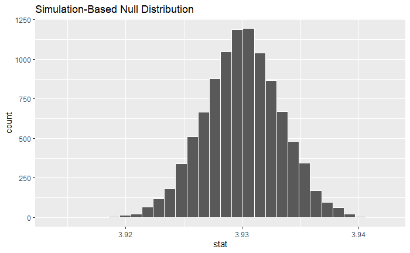

```r
null_distribution %>%
  visualise(bins = 30)
```

```r
observed_stat
```

| mean_rating |
| --- |
| 3.937568 |

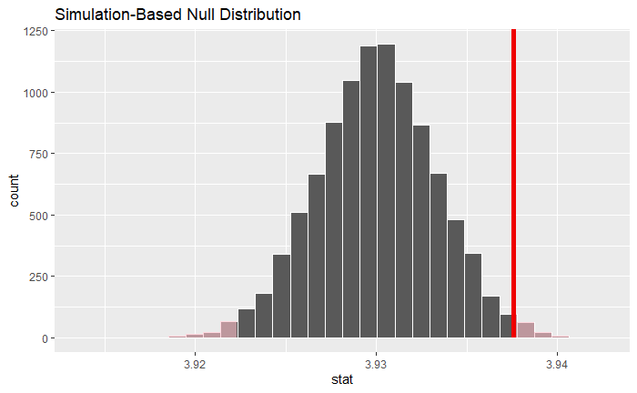

```r
null_distribution %>%
  visualise(bins = 30) +
  shade_p_value(obs_stat =
                  observed_stat$mean_rating,
                direction = "both"
  )
```

Just as best practice is to choose an $\alpha$ value **before** you see the data, you should also set your alternative hypothesis **before** you see the data. Resist the urge to change your alternative hypothesis after seeing the data!

If you’re not sure whether to choose a one-tailed or two-tailed test, select two-tailed, as it’s a more difficult test to pass and is therefore the more skeptical option.

### 6.3 Calculate p-value

```r
p_value <- null_distribution %>%
  get_p_value(obs_stat =
              observed_stat$mean_rating,
              direction = "both")

p_value
```

| p_value |
| --- |
| 0.0212 |